# Grupo 5 - Trabalho prático de Extração de Conhecimento de Bases de Dados Biológicas

Ana Lisboa(pg49831), Angelina Eiras(pg42861), Bruna Almeida(pg51187), Luciana Martins(pg49839)

2023-06-10

## Explicação dos dados, a sua origem e relevância

Os dados escolhidos pelo nosso grupo são provenientes do estudo Skin Cutaneous Melanoma, assumindo o id TCGA-SKCM (The Cancer Genome Atlas-Skin Cutaneous Melanoma), na base de dados National Cancer Institute (GCD Data Portal). O dataset foi obtido através do link: https://portal.gdc.cancer.gov/projects/TCGA-SKCM.

Este conjunto de dados é referente à expressão genómica e perfil molecular de pacientes com melanoma cutâneo contendo informações sobre mais de 400 amostras de tecido de pacientes, incluindo informações clínicas, genómicas e de expressão génica. As amostras foram recolhidas em diferentes locais do corpo e, posteriormente, analisadas para identificar mutações genéticas, alterações no RNA, metilação do DNA e outras características moleculares.

O melanoma cutâneo é causado pela exposição excessiva aos raios ultravioleta do sol e ao bronzeamento artificial, que provocam alterações nos melanócitos, as células produtoras de pigmento da pele.

O projeto tem como objetivo entender melhor as causas do melanoma cutâneo e identificar potenciais alvos terapêuticos, demonstrando como a análise genómica pode ser usada para avançar na compreensão do cancro e ajudar a desenvolver tratamentos mais eficazes.

## Obtenção de packages do BioConductor

```r
if (!requireNamespace("BiocManager", quietly = TRUE))
  install.packages("BiocManager")

if (!requireNamespace("rpart.plot", quietly = TRUE))
  install.packages("rpart.plot")

if (!requireNamespace("org.Hs.eg.db", quietly = TRUE))
  BiocManager::install("org.Hs.eg.db")
if (!requireNamespace("TCGAbiolinks", quietly = TRUE))
  BiocManager::install("TCGAbiolinks")

if (!requireNamespace("MultiAssayExperiment", quietly = TRUE))
  BiocManager::install("MultiAssayExperiment")

if (!requireNamespace("DESeq2", quietly = TRUE))
  BiocManager::install("DESeq2")

if (!requireNamespace("limma", quietly = TRUE))
  BiocManager::install("limma")
```

## Carregamento de packages

```r
library(MultiAssayExperiment)
library(TCGAbiolinks)
library(limma)
library(DESeq2)
library(org.Hs.eg.db)
```

```r
library(rpart)
library(rpart.plot)
library(class)
library(caret)
library(glmnet)
```

## Obtenção dos dados

Começamos por retirar os dados a partir do package TCGAbiolinks e guardamos o ficheiro para ser mais fácil a sua utilização, posteriormente.

```r
proj <- "TCGA-SKCM"
#query <- GDCquery(project = proj, data.category = "Transcriptome Profiling",  data.type = "Gene Expression Quantification", workflow.type = "STAR - Counts")

#if (!file.exists("TCGA_SKCM")) {GDCdownload(query, directory = "TCGA_SKCM", files.per.chunk = 5)}

#data_rna_SKCM <- GDCprepare(query, save = TRUE, save.filename = "TCGA_SKCM.rda")

query <- GDCquery(project = proj, data.category = "Transcriptome Profiling", data.type = "Gene Expression Quantification", workflow.type = "STAR - Counts")
```

```
## o GDCquery: Searching in GDC database
```

```
## Genome of reference: hg38
```

```
## oo Accessing GDC. This might take a while...
```

```
## ooo Project: TCGA-SKCM
```

```
## oo Filtering results
```

```
## ooo By data.type
```

```
## ooo By workflow.type
```

```
## oo Checking data
```

```
## ooo Checking if there are duplicated cases
```

```
## ooo Checking if there are results for the query
```

```
## o Preparing output
```

```r
GDCdownload(query)
```

```
## Of the 473 files for download 473 already exist.
```

```
## All samples have been already downloaded
```

```r
data_rna_SKCM <- GDCprepare(query, save = TRUE, save.filename = "TCGA_SKCM.rda")
```

[output not shown]

[output cut: 420 more lines]

[output not shown]

```
## Starting to add information to samples
```

```
##  => Add clinical information to samples
```

```
##  => Adding TCGA molecular information from marker papers
```

```
##  => Information will have prefix 'paper_'
```

```
## skcm subtype information from:doi:10.1016/j.cell.2015.05.044
```

```
## Available assays in SummarizedExperiment :
##   => unstranded
##   => stranded_first
##   => stranded_second
##   => tpm_unstrand
##   => fpkm_unstrand
##   => fpkm_uq_unstrand
```

```
## => Saving file: TCGA_SKCM.rda
```

```
## => File saved
```

```r
load("TCGA_SKCM.rda")

class(data_rna_SKCM)
```

```
## [1] "RangedSummarizedExperiment"
## attr(,"package")
## [1] "SummarizedExperiment"
```

```r
dim(data_rna_SKCM)
```

```
## [1] 60660   473
```

## Exploração dos Metadados

De seguida realizamos a exploração dos metadados, que consistem nos dados clínicos, contendo informação, como o sexo, ano de diagnóstico, o tipo de células tumorais, entre outros.

```r
#metadados
metadata <- colData(data_rna_SKCM)
dim(metadata)
```

```
## [1] 473 173
```

```r
colnames(metadata)
```

```
##   [1] "barcode"
##   [2] "patient"
##   [3] "sample"
##   [4] "shortLetterCode"
##   [5] "definition"
##   [6] "sample_submitter_id"
##   [7] "sample_type_id"
##   [8] "oct_embedded"
##   [9] "sample_id"
##  [10] "submitter_id"
##  [11] "state"
##  [12] "is_ffpe"
##  [13] "sample_type"
##  [14] "tissue_type"
##  [15] "tumor_descriptor"
```

[output cut: 158 more lines]

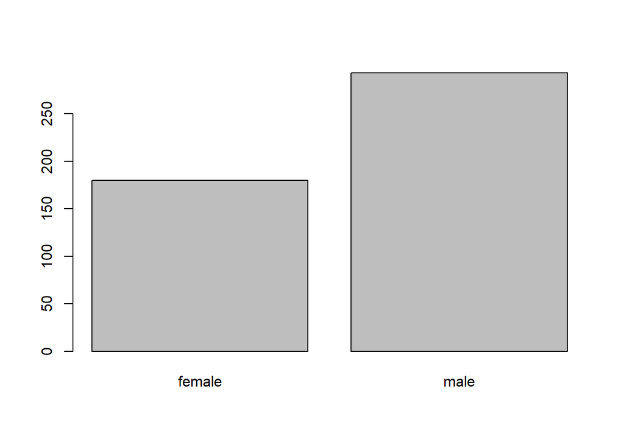

```r
barplot(table(metadata$gender))
```

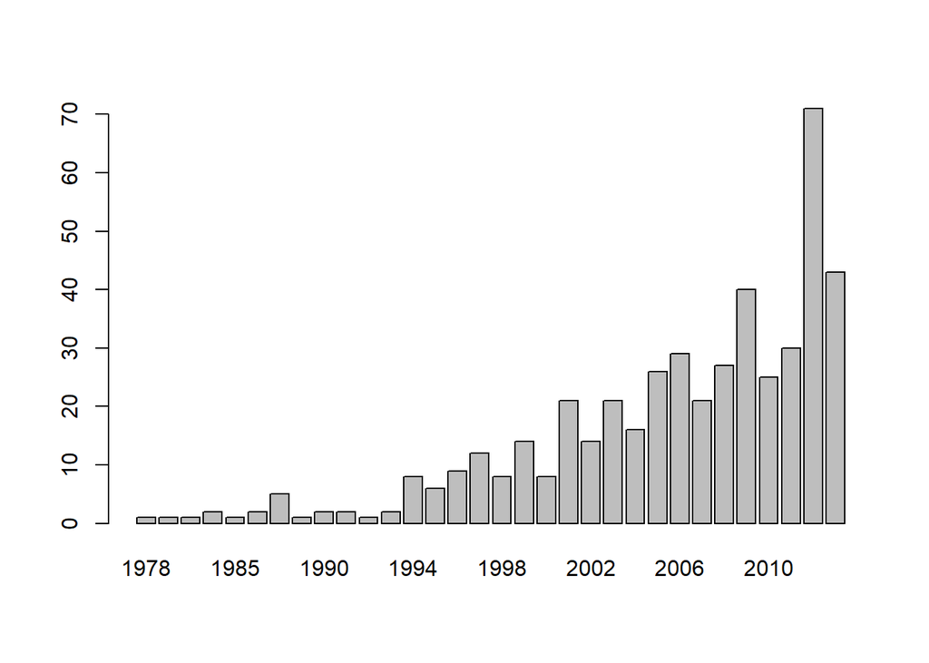

```r
barplot(table(metadata$year_of_diagnosis))
```

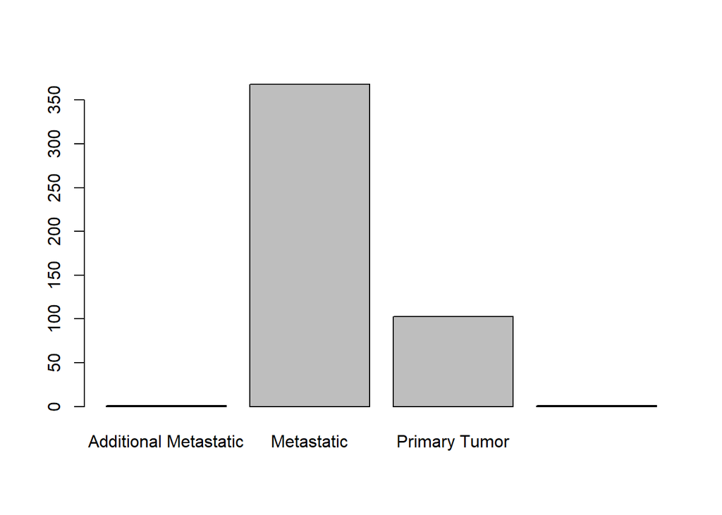

```r
barplot(table(metadata$sample_type))
```

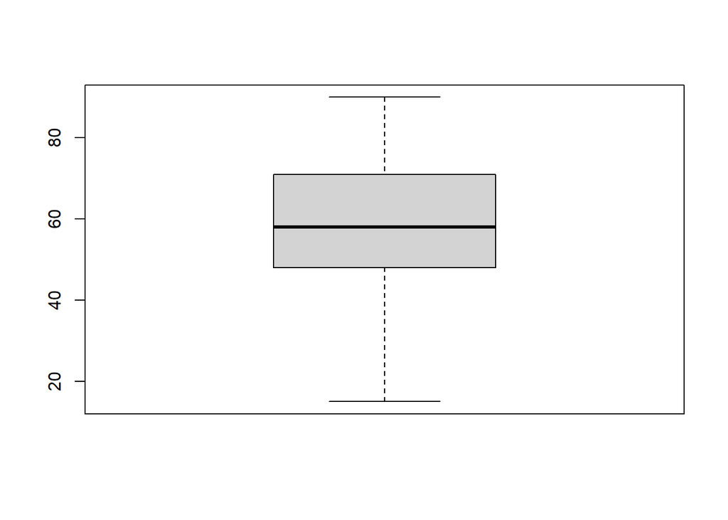

```r
boxplot(metadata$age_at_index)
```

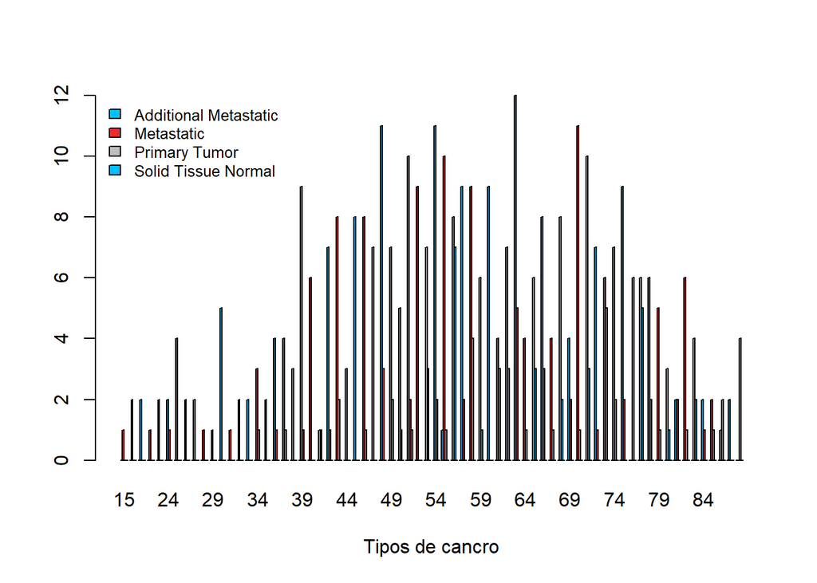

```r
contagens <- table(metadata$sample_type, metadata$age_at_index)
nomes <- c( "Additional Metastatic", "Metastatic", "Primary Tumor", "Solid Tissue Normal")
barplot(contagens, xlab="Tipos de cancro" ,col=c("deepskyblue","firebrick2", "gray"), beside=TRUE)
legend("topleft", legend = nomes, cex = 0.8, bty="n", fill = c("deepskyblue","firebrick2", "gray"))
```

# Sexo vs Metastatic/Primary Tumor - tabela cruzada sem considerar as restantes duas categorias de sample_type.

```r
h_m <- sum(metadata$gender=="male" & metadata$sample_type=="Metastatic")
h_p <- sum(metadata$gender=="male" & metadata$sample_type=="Primary Tumor")
m_m <- sum(metadata$gender=="female" & metadata$sample_type=="Metastatic")
m_p <- sum(metadata$gender=="female" & metadata$sample_type=="Primary Tumor")

dados_tabela_cruzada <- matrix(c(h_m,h_p, m_m,m_p), nrow = 2, ncol = 2, byrow = TRUE, dimnames = list(c("Homem", "Mulher"), c("Metastatic", "Primary Tumor")))
chisq.test(dados_tabela_cruzada)
```

```
##
##  Pearson's Chi-squared test with Yates' continuity correction
##
## data:  dados_tabela_cruzada
## X-squared = 0.24032, df = 1, p-value = 0.624
```

A partir dos barplots realizados inicialmente, concluiu-se que a maior parte dos pacientes são do sexo masculino, de seguida conseguimos perceber que estes foram mais diagnosticados a partir dos anos 2000, com maior incidência em 2012, possívelmente, devido ao avanço da tecnologia. Também podemos verificar que a grande maioria dos nossos dados são do tipo “Metastatic” seguido de “Primary Tumor”. Recorrendo aos dados sample_type e age_at_index, relacionamos a idade e o tipo de amostra. Por último, foi relacionado o sexo com apenas dois tipos de amostra, onde se realizou o Chi-squared test e averiguamos que o p_value é maior que 0.05, assim, não podemos rejeitar a hipótese nula pelo que, não há evidência de que as variáveis estejam relacionadas.

## Exploração dos Metadados 2

```r
rowData(data_rna_SKCM)
```

```
## DataFrame with 60660 rows and 10 columns
##                      source     type     score     phase            gene_id
##                    <factor> <factor> <numeric> <integer>        <character>
## ENSG00000000003.15   HAVANA     gene        NA        NA ENSG00000000003.15
## ENSG00000000005.6    HAVANA     gene        NA        NA  ENSG00000000005.6
## ENSG00000000419.13   HAVANA     gene        NA        NA ENSG00000000419.13
## ENSG00000000457.14   HAVANA     gene        NA        NA ENSG00000000457.14
## ENSG00000000460.17   HAVANA     gene        NA        NA ENSG00000000460.17
## ...                     ...      ...       ...       ...                ...
## ENSG00000288669.1    HAVANA     gene        NA        NA  ENSG00000288669.1
## ENSG00000288670.1    HAVANA     gene        NA        NA  ENSG00000288670.1
## ENSG00000288671.1    HAVANA     gene        NA        NA  ENSG00000288671.1
## ENSG00000288674.1    HAVANA     gene        NA        NA  ENSG00000288674.1
## ENSG00000288675.1    HAVANA     gene        NA        NA  ENSG00000288675.1
##                         gene_type   gene_name       level     hgnc_id
##                       <character> <character> <character> <character>
## ENSG00000000003.15 protein_coding      TSPAN6           2  HGNC:11858
## ENSG00000000005.6  protein_coding        TNMD           2  HGNC:17757
## ENSG00000000419.13 protein_coding        DPM1           2   HGNC:3005
## ENSG00000000457.14 protein_coding       SCYL3           2  HGNC:19285
## ENSG00000000460.17 protein_coding    C1orf112           2  HGNC:25565
## ...                           ...         ...         ...         ...
## ENSG00000288669.1  protein_coding  AC008763.4           2          NA
## ENSG00000288670.1          lncRNA  AL592295.6           2          NA
## ENSG00000288671.1  protein_coding  AC006486.3           2          NA
## ENSG00000288674.1  protein_coding  AL391628.1           2          NA
## ENSG00000288675.1  protein_coding  AP006621.6           2          NA
##                             havana_gene
##                             <character>
## ENSG00000000003.15 OTTHUMG00000022002.2
## ENSG00000000005.6  OTTHUMG00000022001.2
## ENSG00000000419.13 OTTHUMG00000032742.2
## ENSG00000000457.14 OTTHUMG00000035941.6
## ENSG00000000460.17 OTTHUMG00000035821.9
## ...                                 ...
## ENSG00000288669.1                    NA
## ENSG00000288670.1                    NA
## ENSG00000288671.1                    NA
## ENSG00000288674.1                    NA
## ENSG00000288675.1  OTTHUMG00000189301.4
```

```r
names(rowData(data_rna_SKCM))
```

```
##  [1] "source"      "type"        "score"       "phase"       "gene_id"
##  [6] "gene_type"   "gene_name"   "level"       "hgnc_id"     "havana_gene"
```

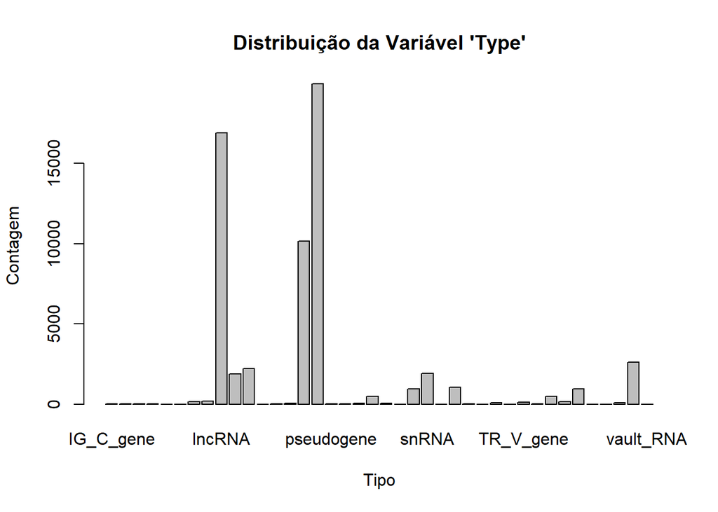

```r
gene_type <- rowData(data_rna_SKCM)$gene_type
barplot(table(gene_type), main="Distribuição da Variável 'Type'", xlab="Tipo", ylab="Contagem")
```

```r
table(rowData(data_rna_SKCM)$source)
```

```
##
##  HAVANA ENSEMBL
##   53065    7595
```

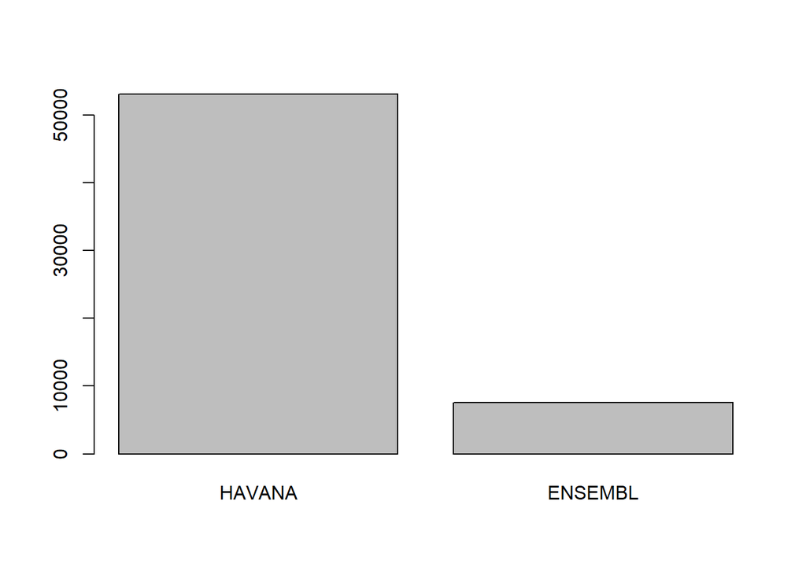

```r
barplot(table(rowData(data_rna_SKCM)$source))
```

```r
table(rowData(data_rna_SKCM)$type)
```

```
##
##           gene     transcript           exon            CDS    start_codon
##          60660              0              0              0              0
##     stop_codon            UTR Selenocysteine
##              0              0              0
```

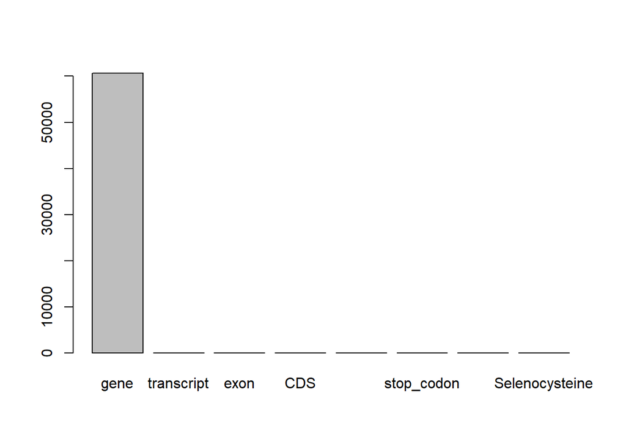

```r
barplot(table(rowData(data_rna_SKCM)$type))
```

## Aplicação do package DESEQ2

Retornando à análise dos dados data_rna_SKCM efetuamos primeiramente aplicação do package DESEQ2 que nos permite distinguir genes diferencialmente expressos.

```r
data_de <- data_rna_SKCM[,!is.na(data_rna_SKCM$paper_IDH1_mut)]

ddsSE <- DESeqDataSet(data_de, design = ~ paper_IDH1_mut)
```

```
## renaming the first element in assays to 'counts'
```

```
## factor levels were dropped which had no samples
```

[output not shown]

```r
keep <- rowSums(counts(ddsSE)) >= 10
ddsSE <- ddsSE[keep,]
ddsSE_2 <- DESeq(ddsSE)
```

[output not shown]

[output not shown]

[output not shown]

[output not shown]

```
## -- replacing outliers and refitting for 15743 genes
## -- DESeq argument 'minReplicatesForReplace' = 7
## -- original counts are preserved in counts(dds)
```

[output not shown]

[output not shown]

```r
counts_ddsSE_2 <- counts(ddsSE_2)

design_ddsSE_2 <- colData(ddsSE_2)
sizeFactors_ddsSE_2 <- sizeFactors(ddsSE_2)

resultsNames(ddsSE_2)
```

```
## [1] "Intercept"                  "paper_IDH1_mut_P33S._vs_."
## [3] "paper_IDH1_mut_R132C._vs_." "paper_IDH1_mut_wt_vs_."
```

```r
res <- results(ddsSE_2, name = "paper_IDH1_mut_wt_vs_.")
df <- as.data.frame(res)
summary(res)
```

```
##
## out of 42745 with nonzero total read count
## adjusted p-value < 0.1
## LFC > 0 (up)       : 238, 0.56%
## LFC < 0 (down)     : 21, 0.049%
## outliers [1]       : 249, 0.58%
## low counts [2]     : 14893, 35%
## (mean count < 2)
## [1] see 'cooksCutoff' argument of ?results
## [2] see 'independentFiltering' argument of ?results
```

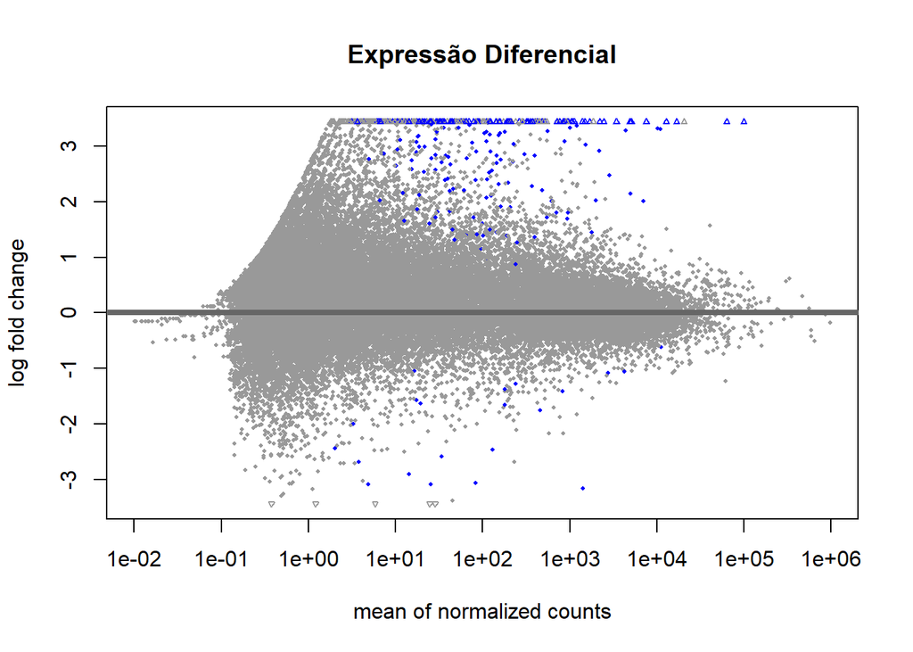

```r
DESeq2::plotMA(res, main = "Expressão Diferencial", ylm = c(-2,2))
```

## Pré-processamento dos dados de expressão genética

Através dos counts_ddsSE_2, foi efetuado o pré-processamento dos dados, como também a filtragem e a normalização destes.

```r
data_df <- as.data.frame(counts_ddsSE_2)
not_na <- complete.cases(data_df)
data_filtered <- counts_ddsSE_2[not_na,]
data_matrix <- as.matrix(assay(data_filtered))

data_norm <- scale(data_matrix)

head(data_norm)
```

```
##                    TCGA-EB-A3Y6-01A-21R-A239-07 TCGA-EB-A4XL-01A-11R-A27Q-07
## ENSG00000000003.15                   0.04467356                   0.18335292
## ENSG00000000005.6                   -0.11855557                  -0.12800780
## ENSG00000000419.13                   0.02998115                  -0.02054997
## ENSG00000000457.14                  -0.01759002                  -0.06793821
## ENSG00000000460.17                  -0.03801606                  -0.09686060
## ENSG00000000938.13                  -0.10896966                  -0.09574820
##                    TCGA-FS-A1ZN-01A-11R-A18T-07 TCGA-EB-A3XB-01A-11R-A239-07
## ENSG00000000003.15                  0.134091616                  0.056696263
## ENSG00000000005.6                  -0.177578348                 -0.096243604
## ENSG00000000419.13                  0.003503643                  0.007852339
## ENSG00000000457.14                 -0.020524545                 -0.043626024
## ENSG00000000460.17                 -0.092725184                 -0.057795034
## ENSG00000000938.13                 -0.168524248                 -0.081647388
##                    TCGA-EB-A44N-01A-11R-A266-07 TCGA-EB-A42Y-01A-12R-A24X-07
## ENSG00000000003.15                   0.04123400                   0.06844730
## ENSG00000000005.6                   -0.14688640                  -0.17423676
## ENSG00000000419.13                   0.04107113                   0.12291589
## ENSG00000000457.14                  -0.04329802                  -0.08153867
## ENSG00000000460.17                  -0.07929336                  -0.06721670
## ENSG00000000938.13                  -0.09444072                  -0.13984148
##                    TCGA-ER-A196-01A-11R-A18T-07 TCGA-ER-A2NB-01A-12R-A18S-07
## ENSG00000000003.15                 -0.002418490                  -0.02364011
## ENSG00000000005.6                  -0.128557025                  -0.04428340
## ENSG00000000419.13                 -0.002020158                  -0.02511463
## ENSG00000000457.14                 -0.097619890                  -0.04058205
## ENSG00000000460.17                 -0.113420401                  -0.04181583
## ENSG00000000938.13                 -0.082616043                  -0.01665870
##                    TCGA-EB-A431-01A-11R-A266-07 TCGA-EB-A550-01A-61R-A27Q-07
## ENSG00000000003.15                   0.03174062                   0.09000787
## ENSG00000000005.6                   -0.13644539                  -0.12691768
## ENSG00000000419.13                   0.07035264                   0.05804113
## ENSG00000000457.14                  -0.05308091                  -0.05979934
## ENSG00000000460.17                  -0.03101691                  -0.09377136
## ENSG00000000938.13                  -0.12031369                  -0.10344396
##                    TCGA-D9-A4Z5-01A-11R-A266-07 TCGA-EB-A3HV-01A-11R-A21D-07
## ENSG00000000003.15                   0.38956152                   0.05808198
## ENSG00000000005.6                   -0.13965784                  -0.12884167
## ENSG00000000419.13                  -0.03361917                  -0.07407479
## ENSG00000000457.14                  -0.08755158                  -0.09023407
```

[output cut: 176 more lines]

```
## ENSG00000000938.13                 -0.060000027                  -0.12509232
##                    TCGA-BF-A5EO-01A-12R-A27Q-07 TCGA-ER-A19K-01A-21R-A18T-07
## ENSG00000000003.15                 -0.005303861                   0.05158693
## ENSG00000000005.6                  -0.115159314                  -0.10844789
## ENSG00000000419.13                 -0.064384913                   0.01480134
## ENSG00000000457.14                 -0.092523691                  -0.07243305
## ENSG00000000460.17                 -0.093146690                  -0.05449569
## ENSG00000000938.13                 -0.054832265                  -0.08462484
##                    TCGA-FR-A2OS-01A-11R-A21D-07 TCGA-BF-A3DL-01A-11R-A20F-07
## ENSG00000000003.15                   0.14015001                   0.03645130
## ENSG00000000005.6                   -0.17739929                  -0.08490521
## ENSG00000000419.13                   0.04775743                  -0.04395999
## ENSG00000000457.14                  -0.08862206                  -0.06802959
## ENSG00000000460.17                  -0.11111765                  -0.06829853
## ENSG00000000938.13                  -0.15630967                  -0.07603038
```

## Análise descritiva

Nesta fase, de modo a proceder à análise descritiva efetuamos gráficos dos dados normalizados para melhor interpretação.

```r
summary(data_norm)
```

```
##  TCGA-EB-A3Y6-01A-21R-A239-07 TCGA-EB-A4XL-01A-11R-A27Q-07
##  Min.   :-0.11856             Min.   : -0.12801
##  1st Qu.:-0.11856             1st Qu.: -0.12790
##  Median :-0.11802             Median : -0.12712
##  Mean   : 0.00000             Mean   :  0.00000
##  3rd Qu.:-0.08382             3rd Qu.: -0.08273
##  Max.   :94.43761             Max.   :104.75606
##  TCGA-FS-A1ZN-01A-11R-A18T-07 TCGA-EB-A3XB-01A-11R-A239-07
##  Min.   :-0.1776              Min.   : -0.09624
##  1st Qu.:-0.1776              1st Qu.: -0.09624
##  Median :-0.1768              Median : -0.09589
##  Mean   : 0.0000              Mean   :  0.00000
##  3rd Qu.:-0.1227              3rd Qu.: -0.07367
##  Max.   :59.2707              Max.   :102.97611
##  TCGA-EB-A44N-01A-11R-A266-07 TCGA-EB-A42Y-01A-12R-A24X-07
##  Min.   :-0.14754             Min.   :-0.1747
##  1st Qu.:-0.14754             1st Qu.:-0.1747
##  Median :-0.14656             Median :-0.1740
##  Mean   : 0.00000             Mean   : 0.0000
##  3rd Qu.:-0.08727             3rd Qu.:-0.1254
##  Max.   :75.53583             Max.   :63.3295
##  TCGA-ER-A196-01A-11R-A18T-07 TCGA-ER-A2NB-01A-12R-A18S-07
##  Min.   :-0.12856             Min.   : -0.04428
##  1st Qu.:-0.12856             1st Qu.: -0.04428
##  Median :-0.12829             Median : -0.04422
##  Mean   : 0.00000             Mean   :  0.00000
##  3rd Qu.:-0.09709             3rd Qu.: -0.03986
##  Max.   :63.65187             Max.   :128.87371
##  TCGA-EB-A431-01A-11R-A266-07 TCGA-EB-A550-01A-61R-A27Q-07
##  Min.   : -0.13645            Min.   :-0.12692
##  1st Qu.: -0.13634            1st Qu.:-0.12680
##  Median : -0.13572            Median :-0.12597
##  Mean   :  0.00000            Mean   : 0.00000
##  3rd Qu.: -0.09971            3rd Qu.:-0.07976
##  Max.   :103.90492            Max.   :71.96927
##  TCGA-D9-A4Z5-01A-11R-A266-07 TCGA-EB-A3HV-01A-11R-A21D-07
##  Min.   :-0.1403              Min.   :-0.12884
##  1st Qu.:-0.1403              1st Qu.:-0.12884
##  Median :-0.1398              Median :-0.12840
##  Mean   : 0.0000              Mean   : 0.00000
```

[output cut: 176 more lines]

```
##  Max.   :103.27829            Max.   :68.3740
##  TCGA-BF-A5EO-01A-12R-A27Q-07 TCGA-ER-A19K-01A-21R-A18T-07
##  Min.   : -0.11516            Min.   :-0.10852
##  1st Qu.: -0.11516            1st Qu.:-0.10852
##  Median : -0.11485            Median :-0.10824
##  Mean   :  0.00000            Mean   : 0.00000
##  3rd Qu.: -0.09387            3rd Qu.:-0.08301
##  Max.   :111.18212            Max.   :96.97271
##  TCGA-FR-A2OS-01A-11R-A21D-07 TCGA-BF-A3DL-01A-11R-A20F-07
##  Min.   :-0.1775              Min.   : -0.08491
##  1st Qu.:-0.1774              1st Qu.: -0.08491
##  Median :-0.1766              Median : -0.08477
##  Mean   : 0.0000              Mean   :  0.00000
##  3rd Qu.:-0.1262              3rd Qu.: -0.07437
##  Max.   :52.1173              Max.   :137.89099
```

```r
subset_data <- data_norm[1:4,]
summary(subset_data)
```

```
##  TCGA-EB-A3Y6-01A-21R-A239-07 TCGA-EB-A4XL-01A-11R-A27Q-07
##  Min.   :-0.118556            Min.   :-0.128008
##  1st Qu.:-0.042831            1st Qu.:-0.082956
##  Median : 0.006196            Median :-0.044244
##  Mean   :-0.015373            Mean   :-0.008286
##  3rd Qu.: 0.033654            3rd Qu.: 0.030426
##  Max.   : 0.044674            Max.   : 0.183353
##  TCGA-FS-A1ZN-01A-11R-A18T-07 TCGA-EB-A3XB-01A-11R-A239-07
##  Min.   :-0.17758             Min.   :-0.09624
##  1st Qu.:-0.05979             1st Qu.:-0.05678
##  Median :-0.00851             Median :-0.01789
##  Mean   :-0.01513             Mean   :-0.01883
##  3rd Qu.: 0.03615             3rd Qu.: 0.02006
##  Max.   : 0.13409             Max.   : 0.05670
##  TCGA-EB-A44N-01A-11R-A266-07 TCGA-EB-A42Y-01A-12R-A24X-07
##  Min.   :-0.146886            Min.   :-0.174237
##  1st Qu.:-0.069195            1st Qu.:-0.104713
##  Median :-0.001113            Median :-0.006546
##  Mean   :-0.026970            Mean   :-0.016103
##  3rd Qu.: 0.041112            3rd Qu.: 0.082064
##  Max.   : 0.041234            Max.   : 0.122916
##  TCGA-ER-A196-01A-11R-A18T-07 TCGA-ER-A2NB-01A-12R-A18S-07
##  Min.   :-0.128557            Min.   :-0.04428
##  1st Qu.:-0.105354            1st Qu.:-0.04151
##  Median :-0.050019            Median :-0.03285
##  Mean   :-0.057654            Mean   :-0.03341
##  3rd Qu.:-0.002319            3rd Qu.:-0.02475
##  Max.   :-0.002020            Max.   :-0.02364
##  TCGA-EB-A431-01A-11R-A266-07 TCGA-EB-A550-01A-61R-A27Q-07
##  Min.   :-0.13645             Min.   :-0.1269177
##  1st Qu.:-0.07392             1st Qu.:-0.0765789
##  Median :-0.01067             Median :-0.0008791
##  Mean   :-0.02186             Mean   :-0.0096670
##  3rd Qu.: 0.04139             3rd Qu.: 0.0660328
##  Max.   : 0.07035             Max.   : 0.0900079
##  TCGA-D9-A4Z5-01A-11R-A266-07 TCGA-EB-A3HV-01A-11R-A21D-07
##  Min.   :-0.13966             Min.   :-0.12884
##  1st Qu.:-0.10058             1st Qu.:-0.09989
##  Median :-0.06059             Median :-0.08215
##  Mean   : 0.03218             Mean   :-0.05877
```

[output cut: 176 more lines]

```
##  Max.   :-0.009979            Max.   : 0.062099
##  TCGA-BF-A5EO-01A-12R-A27Q-07 TCGA-ER-A19K-01A-21R-A18T-07
##  Min.   :-0.115159            Min.   :-0.10845
##  1st Qu.:-0.098183            1st Qu.:-0.08144
##  Median :-0.078454            Median :-0.02882
##  Mean   :-0.069343            Mean   :-0.02862
##  3rd Qu.:-0.049615            3rd Qu.: 0.02400
##  Max.   :-0.005304            Max.   : 0.05159
##  TCGA-FR-A2OS-01A-11R-A21D-07 TCGA-BF-A3DL-01A-11R-A20F-07
##  Min.   :-0.17740             Min.   :-0.08491
##  1st Qu.:-0.11082             1st Qu.:-0.07225
##  Median :-0.02043             Median :-0.05599
##  Mean   :-0.01953             Mean   :-0.04011
##  3rd Qu.: 0.07086             3rd Qu.:-0.02386
##  Max.   : 0.14015             Max.   : 0.03645
```

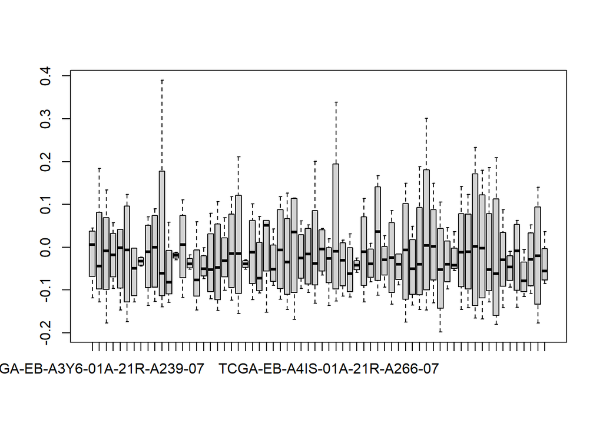

```r
boxplot(subset_data)
```

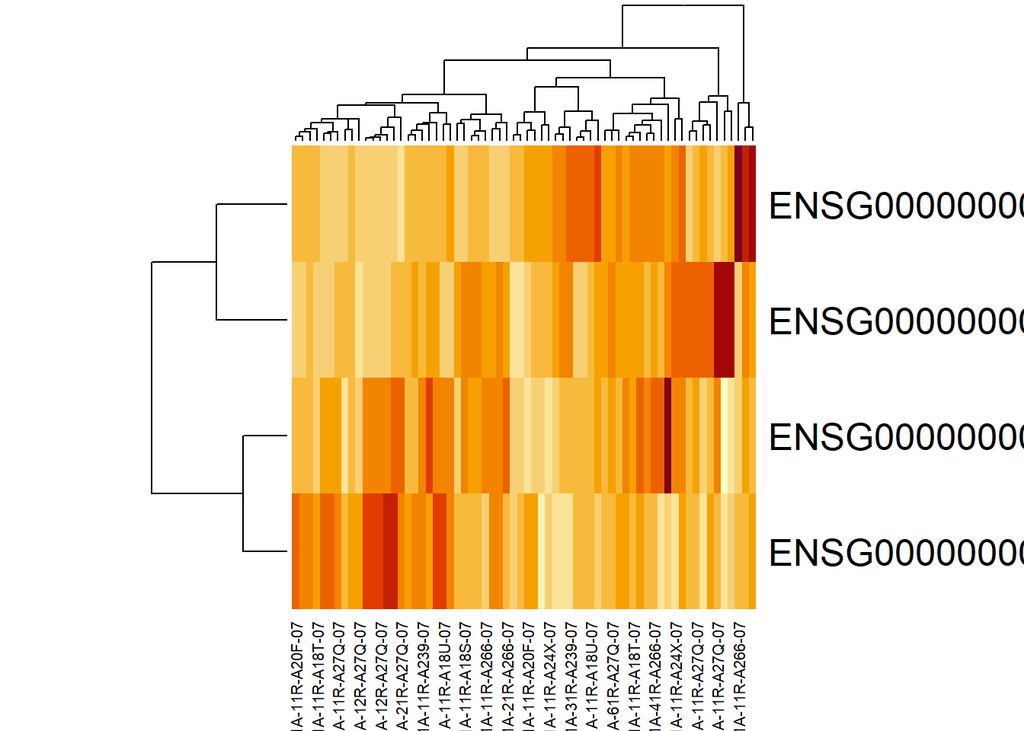

```r
heatmap(subset_data)
```

Ao realizar o heatmap com apenas algumas colunas de genes conseguimos verificar em que pacientes é que alguns se expressam mais e outros menos. A partir deste gráfico uma clusterização é automaticamente feita e podemos verificar do lado esquerdo a clusterização de genes e no topo a dos pacientes, sendo unidos em clusters por semelhança.

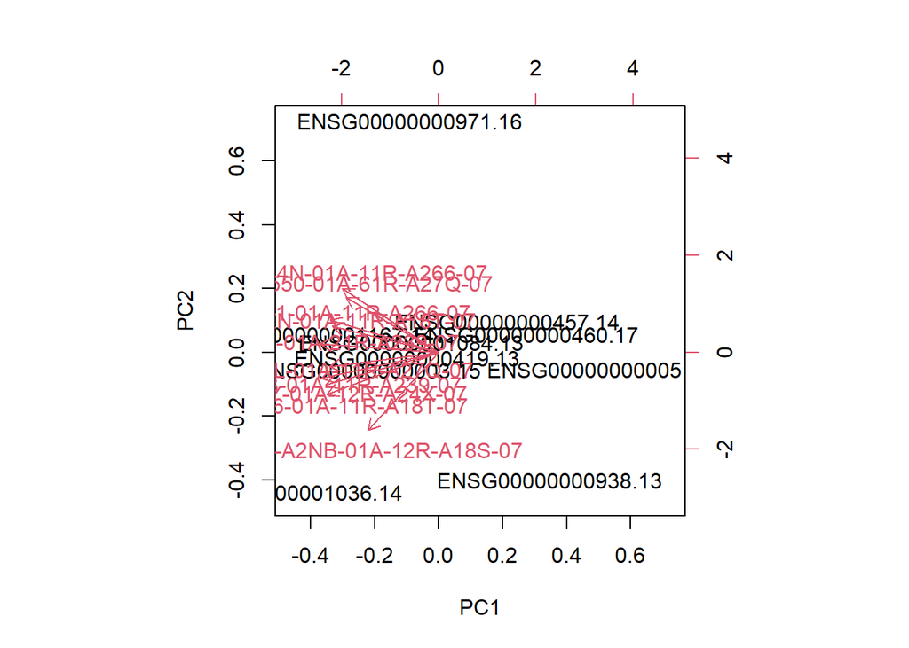

```r
subset_data_2 <- data_norm[1:10, 1:10]

pca <- prcomp(subset_data_2, center = TRUE, scale. = TRUE)
biplot(pca)
```

Apenas com os dados escolhidos para fazer o pca percebemos que existem alguns outliers como os genes “ENSG000000000938.13” e “ENSG00000000971.16” para este grupo de pacientes. É possível analisar um aglumerado de pacientes associados a genes como “ENSG00000000419.13”.

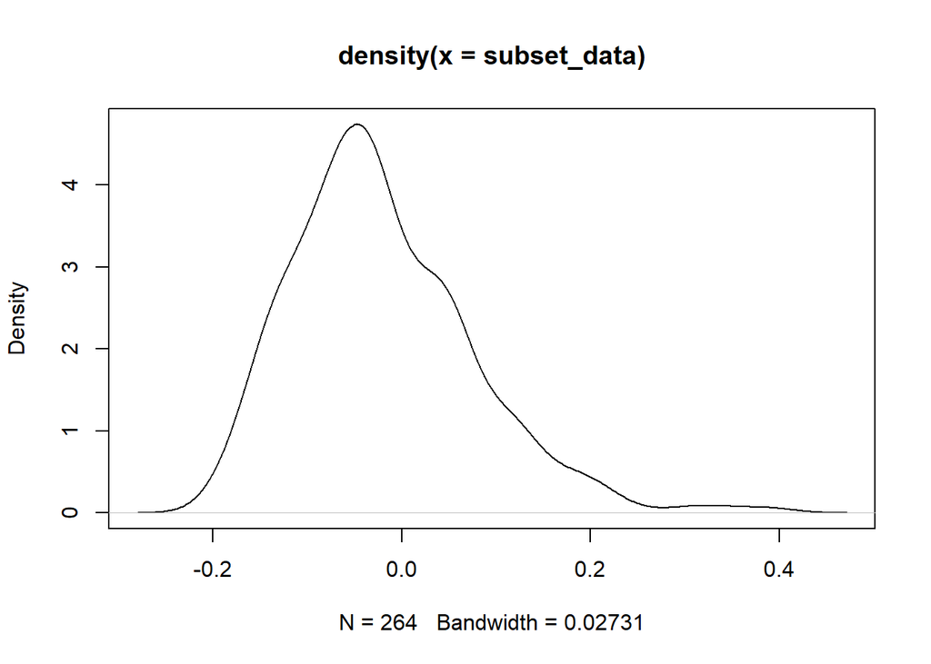

```r
plot(density(subset_data))
```

Verificamos a presença de outliers pela longa cauda do gráfico no lado direito. Devido ao que foi referido e pela não simetria do gráfico (embora em boca de sino) este conjunto de dados pode não ser considerado 100% normalizado.

## Análise de enriquecimento

```r
get_entrez <- function(x){unlist(strsplit(x, split="[.]+"))[2]}

enr <- select(org.Hs.eg.db,keys=sapply(rownames(res), get_entrez),columns=c("ENTREZID","SYMBOL","GENENAME"))
head(enr)
```

```
##   ENTREZID SYMBOL                                  GENENAME
## 1       15  AANAT          aralkylamine N-acetyltransferase
## 2        6   <NA>                                      <NA>
## 3       13  AADAC                 arylacetamide deacetylase
## 4       14   AAMP   angio associated migratory cell protein
## 5       17  AAVS1 adeno-associated virus integration site 1
## 6       13  AADAC                 arylacetamide deacetylase
```

```r
res_2 <- cbind(res, enr)
head(res_2)
```

```
## DataFrame with 6 rows and 9 columns
##                       baseMean log2FoldChange     lfcSE      stat    pvalue
##                      <numeric>      <numeric> <numeric> <numeric> <numeric>
## ENSG00000000003.15 1858.798743     -0.2811714  0.213816 -1.315018 0.1885040
## ENSG00000000005.6     0.753759      1.1167799  1.122665  0.994758 0.3198540
## ENSG00000000419.13 1349.334571     -0.2002578  0.192076 -1.042596 0.2971353
## ENSG00000000457.14  559.690417      0.1027807  0.195880  0.524713 0.5997829
## ENSG00000000460.17  449.972169      0.0792617  0.251611  0.315017 0.7527489
## ENSG00000000938.13  371.191881      0.8961287  0.482627  1.856772 0.0633436
##                         padj    ENTREZID      SYMBOL               GENENAME
##                    <numeric> <character> <character>            <character>
## ENSG00000000003.15  0.770690          15       AANAT aralkylamine N-acety..
## ENSG00000000005.6         NA           6          NA                     NA
## ENSG00000000419.13  0.846261          13       AADAC arylacetamide deacet..
## ENSG00000000457.14  0.951629          14        AAMP angio associated mig..
## ENSG00000000460.17  0.974419          17       AAVS1 adeno-associated vir..
## ENSG00000000938.13  0.586817          13       AADAC arylacetamide deacet..
```

## CLUSTERING HIERARQUICO

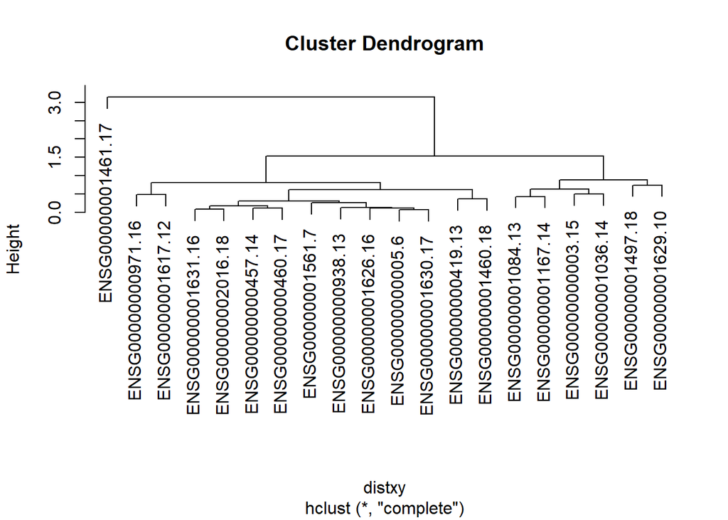

```r
subset <- data_norm[1:20, 1:20]

distxy <- dist(subset, method = "euclidean")
hc = hclust(distxy)
plot(hc)
```

Visualização de um clustering hierarquico com base no subset criado.

# CLUSTERING HIERARQUICO c/TRANSPOSTA

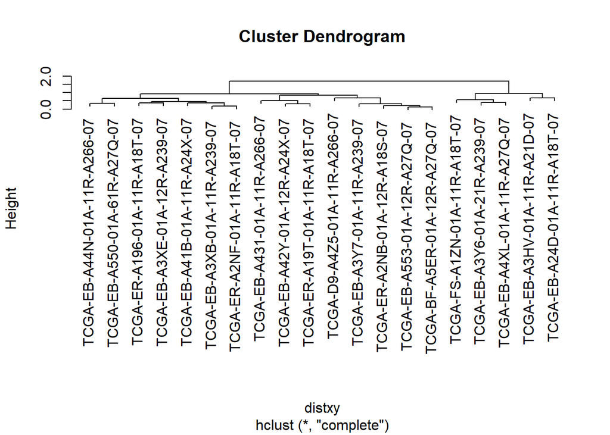

```r
transpose <- t(data_norm)
subset <- transpose[1:20, 1:20]

distxy <- dist(subset, method = "euclidean")
hc = hclust(distxy)
plot(hc)
```

Visualização de um clustering hierarquico com base no subset criado.

## CLUSTERING K-MEANS

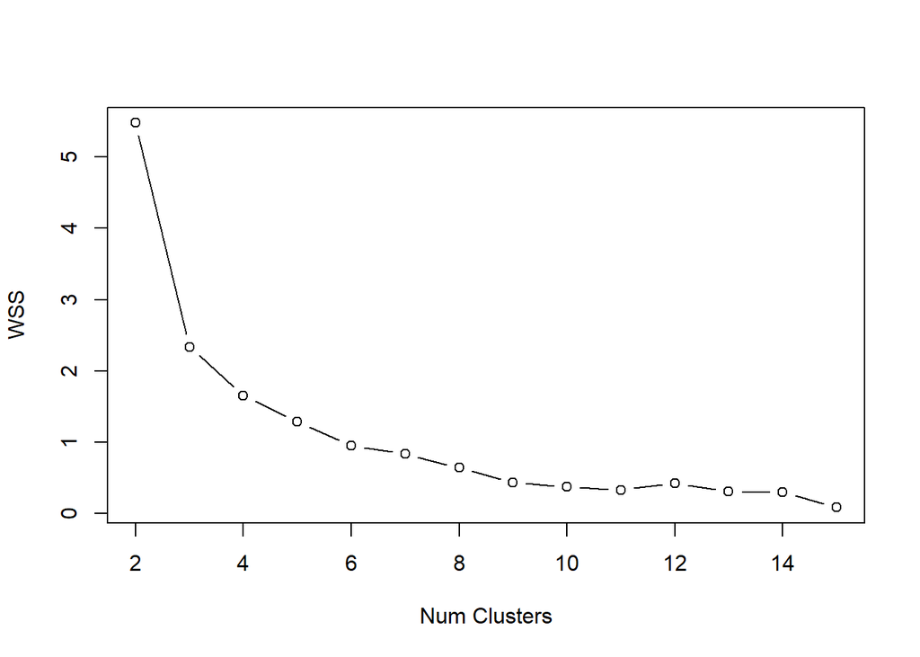

```r
subset <- data_norm[1:20, 1:20]

wss = c()
for (k in 2:15) wss = c(wss, sum(kmeans(subset, centers=k)$withinss) )
plot(2:15, wss, type="b", xlab="Num Clusters", ylab="WSS")
```

```r
clust_res = kmeans(subset, 2)
clust_res$cluster
```

```
## ENSG00000000003.15  ENSG00000000005.6 ENSG00000000419.13 ENSG00000000457.14
##                  1                  1                  1                  1
## ENSG00000000460.17 ENSG00000000938.13 ENSG00000000971.16 ENSG00000001036.14
##                  1                  1                  1                  2
## ENSG00000001084.13 ENSG00000001167.14 ENSG00000001460.18 ENSG00000001461.17
##                  1                  2                  1                  2
## ENSG00000001497.18  ENSG00000001561.7 ENSG00000001617.12 ENSG00000001626.16
##                  2                  1                  1                  1
## ENSG00000001629.10 ENSG00000001630.17 ENSG00000001631.16 ENSG00000002016.18
##                  2                  1                  1                  1
```

O ponto de “cotovelo” é o ponto no gráfico onde a adição de mais clusters não resulta em uma redução significativa na variância explicada. Neste caso será o 3, sendo que a partir desse ponto, adicionar mais clusters provavelmente não fornecerá um ganho significativo no agrupamento dos dados.

## CLUSTERING K-MEANS c/TRANSPOSTA

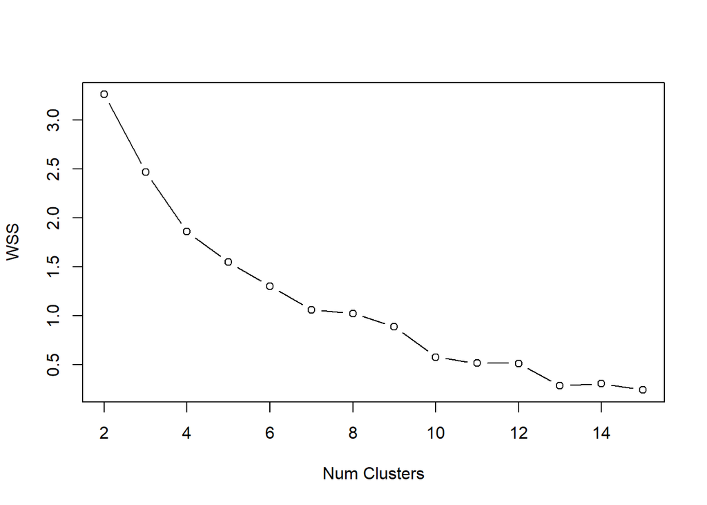

```r
transpose <- t(data_norm)
subset <- transpose[1:20, 1:20]

wss = c()
for (k in 2:15) wss = c(wss, sum(kmeans(subset, centers=k)$withinss) )
plot(2:15, wss, type="b", xlab="Num Clusters", ylab="WSS")
```

```r
clust_res = kmeans(subset, 2)
clust_res$cluster
```

```
## TCGA-EB-A3Y6-01A-21R-A239-07 TCGA-EB-A4XL-01A-11R-A27Q-07
##                            2                            1
## TCGA-FS-A1ZN-01A-11R-A18T-07 TCGA-EB-A3XB-01A-11R-A239-07
##                            1                            2
## TCGA-EB-A44N-01A-11R-A266-07 TCGA-EB-A42Y-01A-12R-A24X-07
##                            2                            2
## TCGA-ER-A196-01A-11R-A18T-07 TCGA-ER-A2NB-01A-12R-A18S-07
##                            2                            2
## TCGA-EB-A431-01A-11R-A266-07 TCGA-EB-A550-01A-61R-A27Q-07
##                            2                            2
## TCGA-D9-A4Z5-01A-11R-A266-07 TCGA-EB-A3HV-01A-11R-A21D-07
##                            2                            1
## TCGA-EB-A553-01A-12R-A27Q-07 TCGA-EB-A24D-01A-11R-A18T-07
##                            2                            1
## TCGA-BF-A5ER-01A-12R-A27Q-07 TCGA-ER-A19T-01A-11R-A18T-07
##                            2                            2
## TCGA-EB-A3Y7-01A-11R-A239-07 TCGA-EB-A3XE-01A-12R-A239-07
##                            2                            2
## TCGA-EB-A41B-01A-11R-A24X-07 TCGA-ER-A2NF-01A-11R-A18T-07
##                            2                            2
```

O ponto de “cotovelo” é o ponto no gráfico onde a adição de mais clusters não resulta em uma redução significativa na variância explicada. Neste caso será o 7, sendo que a partir desse ponto, adicionar mais clusters provavelmente não fornecerá um ganho significativo no agrupamento dos dados.

## PCA

```r
subset <- data_norm[1:20, 1:20]

pcares <- prcomp(subset, scale = T)
summary(pcares) #importancias da componentes
```

```
## Importance of components:
##                          PC1    PC2     PC3     PC4     PC5    PC6     PC7
## Standard deviation     3.600 1.6234 1.34897 1.04765 0.66232 0.6067 0.49238
## Proportion of Variance 0.648 0.1318 0.09099 0.05488 0.02193 0.0184 0.01212
## Cumulative Proportion  0.648 0.7798 0.87078 0.92566 0.94759 0.9660 0.97812
##                            PC8     PC9    PC10    PC11    PC12    PC13    PC14
## Standard deviation     0.41277 0.33596 0.26519 0.20620 0.13642 0.11091 0.07432
## Proportion of Variance 0.00852 0.00564 0.00352 0.00213 0.00093 0.00062 0.00028
## Cumulative Proportion  0.98664 0.99228 0.99580 0.99792 0.99885 0.99947 0.99974
##                           PC15    PC16    PC17     PC18     PC19      PC20
## Standard deviation     0.05341 0.03868 0.02605 0.009051 0.000674 5.091e-17
## Proportion of Variance 0.00014 0.00007 0.00003 0.000000 0.000000 0.000e+00
## Cumulative Proportion  0.99989 0.99996 1.00000 1.000000 1.000000 1.000e+00
```

```r
pcares2 <- princomp(scale(subset))
summary(pcares2) #importancias da componentes
```

```
## Importance of components:
##                          Comp.1    Comp.2     Comp.3     Comp.4     Comp.5
## Standard deviation     3.508914 1.5822882 1.31481447 1.02112722 0.64555153
## Proportion of Variance 0.648025 0.1317703 0.09098616 0.05487899 0.02193351
## Cumulative Proportion  0.648025 0.7797953 0.87078150 0.92566049 0.94759400
##                            Comp.6     Comp.7      Comp.8      Comp.9
## Standard deviation     0.59129929 0.47991232 0.402322532 0.327456089
## Proportion of Variance 0.01840183 0.01212189 0.008519127 0.005643552
## Cumulative Proportion  0.96599583 0.97811772 0.986636848 0.992280400
##                            Comp.10     Comp.11      Comp.12      Comp.13
## Standard deviation     0.258479129 0.200976668 0.1329670050 0.1081051225
## Proportion of Variance 0.003516393 0.002125875 0.0009305381 0.0006150904
## Cumulative Proportion  0.995796793 0.997922668 0.9988532061 0.9994682965
##                             Comp.14      Comp.15      Comp.16      Comp.17
## Standard deviation     0.0724401522 0.0520612485 3.770154e-02 2.539190e-02
## Proportion of Variance 0.0002761882 0.0001426512 7.481086e-05 3.393412e-05
## Cumulative Proportion  0.9997444847 0.9998871359 9.999619e-01 9.999959e-01
##                             Comp.18      Comp.19      Comp.20
## Standard deviation     8.822228e-03 6.569391e-04 7.949401e-09
## Proportion of Variance 4.096406e-06 2.271416e-08 3.325946e-18
## Cumulative Proportion  1.000000e+00 1.000000e+00 1.000000e+00
```

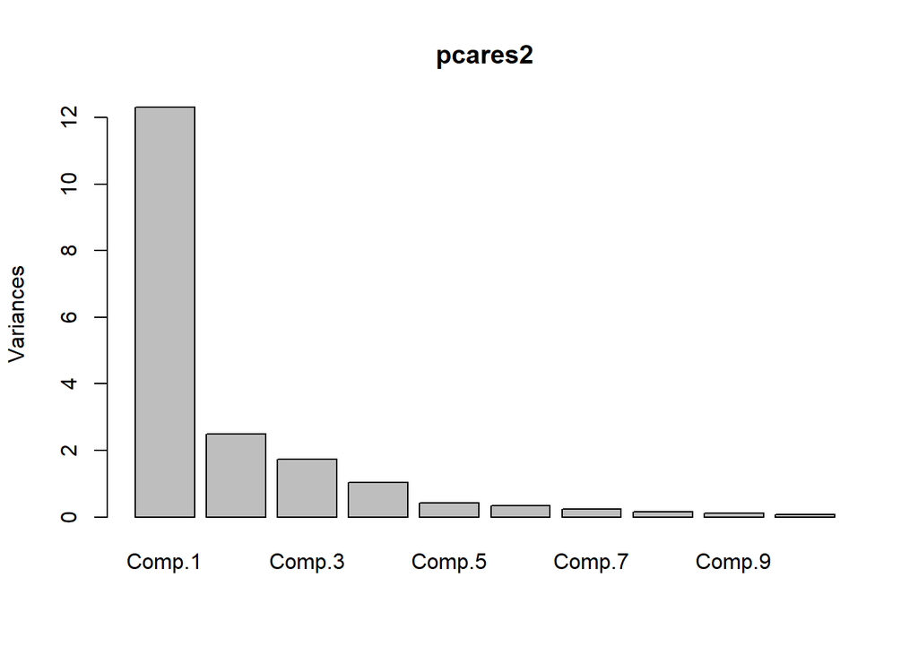

```r
plot(pcares2)
```

```r
pcares2$loadings #loadings
```

```
##
## Loadings:
##                              Comp.1 Comp.2 Comp.3 Comp.4 Comp.5 Comp.6 Comp.7
## TCGA-EB-A3Y6-01A-21R-A239-07  0.257  0.120         0.185  0.105  0.195
## TCGA-EB-A4XL-01A-11R-A27Q-07  0.249  0.236               -0.152 -0.179  0.200
## TCGA-FS-A1ZN-01A-11R-A18T-07  0.255  0.202  0.126         0.111        -0.116
## TCGA-EB-A3XB-01A-11R-A239-07  0.263 -0.119  0.159               -0.135
## TCGA-EB-A44N-01A-11R-A266-07  0.233        -0.147 -0.404 -0.162  0.311 -0.224
## TCGA-EB-A42Y-01A-12R-A24X-07  0.199 -0.307  0.270 -0.244  0.118         0.224
## TCGA-ER-A196-01A-11R-A18T-07  0.245        -0.248 -0.176  0.212 -0.307  0.124
## TCGA-ER-A2NB-01A-12R-A18S-07        -0.114 -0.629 -0.376  0.194 -0.193 -0.117
## TCGA-EB-A431-01A-11R-A266-07  0.221         0.304 -0.269  0.291  0.296
## TCGA-EB-A550-01A-61R-A27Q-07  0.230  0.220 -0.209 -0.223 -0.241  0.192
## TCGA-D9-A4Z5-01A-11R-A266-07  0.176 -0.360               -0.595 -0.392
## TCGA-EB-A3HV-01A-11R-A21D-07  0.214  0.347 -0.130  0.168        -0.104  0.291
## TCGA-EB-A553-01A-12R-A27Q-07  0.186 -0.391 -0.118         0.110  0.389  0.333
## TCGA-EB-A24D-01A-11R-A18T-07  0.228  0.311         0.114  0.211 -0.172
## TCGA-BF-A5ER-01A-12R-A27Q-07  0.193 -0.323 -0.192  0.243  0.224 -0.149 -0.318
## TCGA-ER-A19T-01A-11R-A18T-07  0.220 -0.179  0.285 -0.226  0.109 -0.248  0.239
## TCGA-EB-A3Y7-01A-11R-A239-07  0.189 -0.271 -0.224  0.436         0.209
## TCGA-EB-A3XE-01A-12R-A239-07  0.250        -0.175  0.150 -0.351  0.143  0.291
## TCGA-EB-A41B-01A-11R-A24X-07  0.255                0.259  0.121 -0.140 -0.386
## TCGA-ER-A2NF-01A-11R-A18T-07  0.258         0.122        -0.264  0.204 -0.456
##                              Comp.8 Comp.9 Comp.10 Comp.11 Comp.12 Comp.13
## TCGA-EB-A3Y6-01A-21R-A239-07  0.131  0.425  0.423   0.223   0.474   0.169
## TCGA-EB-A4XL-01A-11R-A27Q-07 -0.126                                 0.111
## TCGA-FS-A1ZN-01A-11R-A18T-07         0.167 -0.154  -0.304
## TCGA-EB-A3XB-01A-11R-A239-07        -0.302                  0.197   0.143
## TCGA-EB-A44N-01A-11R-A266-07  0.270                                 0.297
## TCGA-EB-A42Y-01A-12R-A24X-07        -0.366         -0.315   0.373
## TCGA-ER-A196-01A-11R-A18T-07  0.136         0.160  -0.151
## TCGA-ER-A2NB-01A-12R-A18S-07 -0.337                 0.106           0.192
## TCGA-EB-A431-01A-11R-A266-07 -0.369 -0.100  0.464   0.205  -0.393
## TCGA-EB-A550-01A-61R-A27Q-07        -0.149                  0.204  -0.787
## TCGA-D9-A4Z5-01A-11R-A266-07 -0.283  0.253  0.328
## TCGA-EB-A3HV-01A-11R-A21D-07                               -0.356
## TCGA-EB-A553-01A-12R-A27Q-07 -0.147  0.319 -0.210  -0.425  -0.215
## TCGA-EB-A24D-01A-11R-A18T-07         0.206         -0.205   0.150
## TCGA-BF-A5ER-01A-12R-A27Q-07  0.547         0.239          -0.251  -0.206
## TCGA-ER-A19T-01A-11R-A18T-07  0.203  0.244 -0.429   0.558  -0.153  -0.116
```

[output cut: 44 more lines]

```
## TCGA-EB-A41B-01A-11R-A24X-07  0.207
## TCGA-ER-A2NF-01A-11R-A18T-07  0.266
##
##                Comp.1 Comp.2 Comp.3 Comp.4 Comp.5 Comp.6 Comp.7 Comp.8 Comp.9
## SS loadings      1.00   1.00   1.00   1.00   1.00   1.00   1.00   1.00   1.00
## Proportion Var   0.05   0.05   0.05   0.05   0.05   0.05   0.05   0.05   0.05
## Cumulative Var   0.05   0.10   0.15   0.20   0.25   0.30   0.35   0.40   0.45
##                Comp.10 Comp.11 Comp.12 Comp.13 Comp.14 Comp.15 Comp.16 Comp.17
## SS loadings       1.00    1.00    1.00    1.00    1.00    1.00    1.00    1.00
## Proportion Var    0.05    0.05    0.05    0.05    0.05    0.05    0.05    0.05
## Cumulative Var    0.50    0.55    0.60    0.65    0.70    0.75    0.80    0.85
##                Comp.18 Comp.19 Comp.20
## SS loadings       1.00    1.00    1.00
## Proportion Var    0.05    0.05    0.05
## Cumulative Var    0.90    0.95    1.00
```

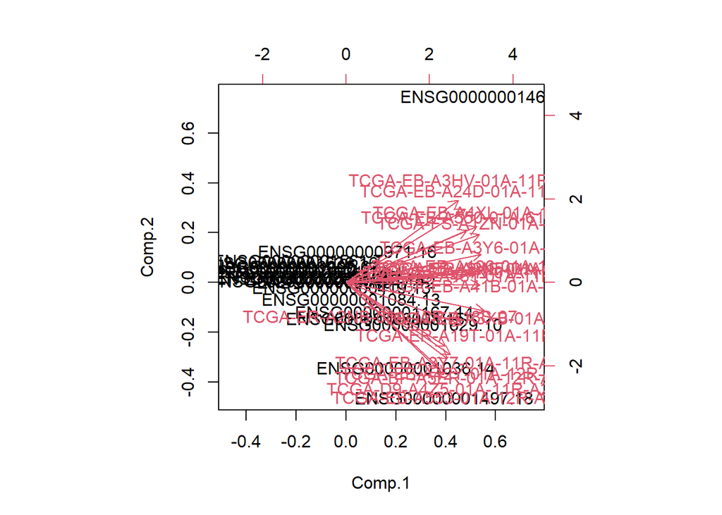

```r
biplot(pcares2)
```

```r
svdres= svd(scale(subset))
svdres$v #as colunas de v são equivalentes aos loadings resultantes da PCA
```

```
##              [,1]        [,2]        [,3]         [,4]          [,5]
##  [1,] -0.25744710 -0.11952439 -0.03982061 -0.185343431 -0.1054296076
##  [2,] -0.24926716 -0.23608633  0.03099433 -0.096399957  0.1522053715
##  [3,] -0.25467791 -0.20232906 -0.12562327  0.028181496 -0.1111759120
##  [4,] -0.26300231  0.11911633 -0.15909278  0.010262904  0.0005159017
##  [5,] -0.23296158 -0.03731485  0.14659671  0.403987146  0.1616388106
##  [6,] -0.19880503  0.30657300 -0.27009440  0.244054334 -0.1184168528
##  [7,] -0.24531685 -0.05690301  0.24798391  0.176274919 -0.2120403320
##  [8,] -0.05216954  0.11357039  0.62916597  0.376460443 -0.1936991754
##  [9,] -0.22143217 -0.02460264 -0.30373868  0.269337895 -0.2912878684
## [10,] -0.23033650 -0.22003271  0.20948575  0.222974600  0.2408744799
## [11,] -0.17578540  0.35968244 -0.09392487  0.029551726  0.5951877419
## [12,] -0.21380283 -0.34714706  0.12958018 -0.168154023 -0.0203959056
## [13,] -0.18633674  0.39120609  0.11776596 -0.076766532 -0.1099394232
## [14,] -0.22799516 -0.31145273 -0.09529351 -0.114188265 -0.2105906470
```

[output cut: 69 more lines]

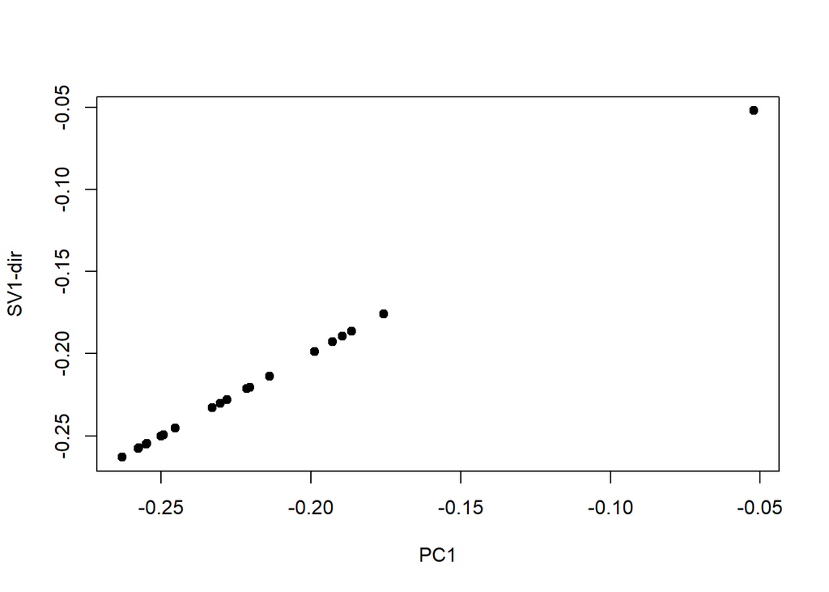

```r
plot(pcares$rotation[,1], svdres$v[,1], pch=19, xlab="PC1", ylab="SV1-dir") #as colunas de v são equivalentes aos loadings resultantes da PCA
```

```r
min(which(summary(pcares)$importance[3,]>0.9)) #número minimo de componentes para explicar 90% da variabilidade do modelo
```

```
## [1] 4
```

#PCA c/TRANSPOSTA

```r
transpose <- t(data_norm)
subset <- transpose[1:20, 1:20]

pcares <- prcomp(subset, scale = T)
summary(pcares)  #importancias da componentes
```

```
## Importance of components:
##                           PC1    PC2    PC3    PC4     PC5     PC6     PC7
## Standard deviation     2.9194 1.7777 1.4202 1.3755 1.08519 0.93741 0.84230
## Proportion of Variance 0.4262 0.1580 0.1008 0.0946 0.05888 0.04394 0.03547
## Cumulative Proportion  0.4262 0.5842 0.6850 0.7796 0.83849 0.88243 0.91790
##                            PC8     PC9    PC10    PC11    PC12    PC13    PC14
## Standard deviation     0.69106 0.57651 0.52667 0.49525 0.36238 0.29501 0.19218
## Proportion of Variance 0.02388 0.01662 0.01387 0.01226 0.00657 0.00435 0.00185
## Cumulative Proportion  0.94178 0.95840 0.97227 0.98453 0.99110 0.99545 0.99729
##                           PC15    PC16    PC17    PC18    PC19      PC20
## Standard deviation     0.16578 0.12468 0.08715 0.05788 0.01185 6.492e-17
## Proportion of Variance 0.00137 0.00078 0.00038 0.00017 0.00001 0.000e+00
## Cumulative Proportion  0.99867 0.99945 0.99983 0.99999 1.00000 1.000e+00
```

```r
pcares2 <- princomp(scale(subset))
summary(pcares2)  #importancias da componentes
```

```
## Importance of components:
##                           Comp.1    Comp.2    Comp.3     Comp.4     Comp.5
## Standard deviation     2.8455256 1.7326722 1.3842251 1.34063979 1.05771368
## Proportion of Variance 0.4261587 0.1580080 0.1008463 0.09459553 0.05888201
## Cumulative Proportion  0.4261587 0.5841668 0.6850130 0.77960857 0.83849058
##                            Comp.6     Comp.7     Comp.8     Comp.9    Comp.10
## Standard deviation     0.91367203 0.82096877 0.67356113 0.56191655 0.51333844
## Proportion of Variance 0.04393666 0.03547314 0.02387814 0.01661843 0.01386928
## Cumulative Proportion  0.88242725 0.91790039 0.94177853 0.95839696 0.97226624
##                           Comp.11     Comp.12     Comp.13     Comp.14
## Standard deviation     0.48271393 0.353202246 0.287541521 0.187318675
## Proportion of Variance 0.01226383 0.006565886 0.004351586 0.001846752
## Cumulative Proportion  0.98453007 0.991095955 0.995447541 0.997294292
##                            Comp.15      Comp.16      Comp.17      Comp.18
## Standard deviation     0.161586338 0.1215206954 0.0849416617 0.0564136625
## Proportion of Variance 0.001374218 0.0007772252 0.0003797414 0.0001675001
## Cumulative Proportion  0.998668511 0.9994457358 0.9998254772 0.9999929773
##                             Comp.19      Comp.20
## Standard deviation     1.155127e-02 1.195636e-08
## Proportion of Variance 7.022727e-06 7.523925e-18
## Cumulative Proportion  1.000000e+00 1.000000e+00
```

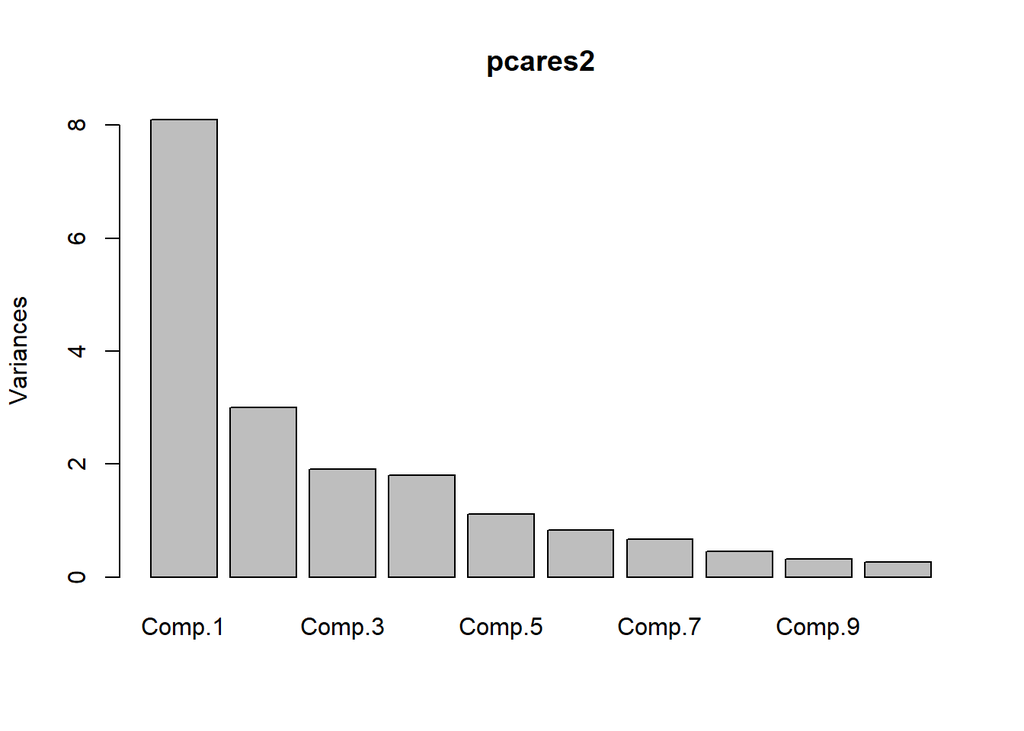

```r
plot(pcares2)
```

```r
pcares2$loadings #loadings
```

```
##
## Loadings:
##                    Comp.1 Comp.2 Comp.3 Comp.4 Comp.5 Comp.6 Comp.7 Comp.8
## ENSG00000000003.15  0.188         0.196         0.579  0.292  0.268  0.131
## ENSG00000000005.6  -0.334         0.118                              0.120
## ENSG00000000419.13        -0.274 -0.390        -0.196  0.122  0.437  0.582
## ENSG00000000457.14 -0.147 -0.407 -0.139 -0.102  0.314        -0.158
## ENSG00000000460.17 -0.221 -0.378         0.114 -0.198  0.139 -0.140
## ENSG00000000938.13 -0.317  0.136                             -0.120  0.233
## ENSG00000000971.16               -0.601         0.347               -0.251
## ENSG00000001036.14  0.199  0.305         0.199 -0.147  0.323 -0.335  0.353
## ENSG00000001084.13  0.201 -0.237  0.139  0.334  0.214 -0.275 -0.195
## ENSG00000001167.14  0.216 -0.360        -0.103  0.136 -0.244         0.164
## ENSG00000001460.18                0.126 -0.618 -0.225         0.379
## ENSG00000001461.17  0.126               -0.554  0.127 -0.118 -0.458  0.208
## ENSG00000001497.18  0.236 -0.129        -0.253         0.483 -0.223  0.165
## ENSG00000001561.7  -0.206 -0.216 -0.231                0.451 -0.153 -0.325
## ENSG00000001617.12         0.286 -0.473         0.132 -0.356 -0.123  0.121
## ENSG00000001626.16 -0.304        -0.105         0.123                0.278
## ENSG00000001629.10  0.229 -0.344 -0.108  0.193        -0.194
## ENSG00000001630.17 -0.322         0.146
## ENSG00000001631.16 -0.314 -0.158                                     0.268
## ENSG00000002016.18 -0.276         0.181         0.407         0.221
##                    Comp.9 Comp.10 Comp.11 Comp.12 Comp.13 Comp.14 Comp.15
## ENSG00000000003.15  0.328          0.266   0.120           0.178
## ENSG00000000005.6                          0.130   0.212
## ENSG00000000419.13                                 0.113          -0.213
## ENSG00000000457.14 -0.428 -0.138   0.293   0.184  -0.200          -0.158
## ENSG00000000460.17         0.126   0.195  -0.177  -0.112           0.403
## ENSG00000000938.13        -0.194   0.197  -0.174   0.423   0.231   0.200
## ENSG00000000971.16 -0.272  0.261  -0.147  -0.167   0.430           0.127
## ENSG00000001036.14 -0.111  0.207          -0.196          -0.438
## ENSG00000001084.13         0.270  -0.417  -0.272   0.108   0.296  -0.167
## ENSG00000001167.14        -0.374  -0.210           0.269  -0.551
## ENSG00000001460.18         0.239  -0.176  -0.270
## ENSG00000001461.17  0.229  0.312   0.296                          -0.178
## ENSG00000001497.18 -0.161 -0.271  -0.406                   0.329   0.336
## ENSG00000001561.7   0.589         -0.155                  -0.103  -0.279
## ENSG00000001617.12  0.281 -0.357  -0.103  -0.129  -0.309   0.141   0.187
## ENSG00000001626.16         0.397  -0.390   0.511  -0.294  -0.100   0.102
```

[output cut: 23 more lines]

```
## ENSG00000001631.16 -0.324           0.347   0.541
## ENSG00000002016.18 -0.198  -0.102  -0.260  -0.299
##
##                Comp.1 Comp.2 Comp.3 Comp.4 Comp.5 Comp.6 Comp.7 Comp.8 Comp.9
## SS loadings      1.00   1.00   1.00   1.00   1.00   1.00   1.00   1.00   1.00
## Proportion Var   0.05   0.05   0.05   0.05   0.05   0.05   0.05   0.05   0.05
## Cumulative Var   0.05   0.10   0.15   0.20   0.25   0.30   0.35   0.40   0.45
##                Comp.10 Comp.11 Comp.12 Comp.13 Comp.14 Comp.15 Comp.16 Comp.17
## SS loadings       1.00    1.00    1.00    1.00    1.00    1.00    1.00    1.00
## Proportion Var    0.05    0.05    0.05    0.05    0.05    0.05    0.05    0.05
## Cumulative Var    0.50    0.55    0.60    0.65    0.70    0.75    0.80    0.85
##                Comp.18 Comp.19 Comp.20
## SS loadings       1.00    1.00    1.00
## Proportion Var    0.05    0.05    0.05
## Cumulative Var    0.90    0.95    1.00
```

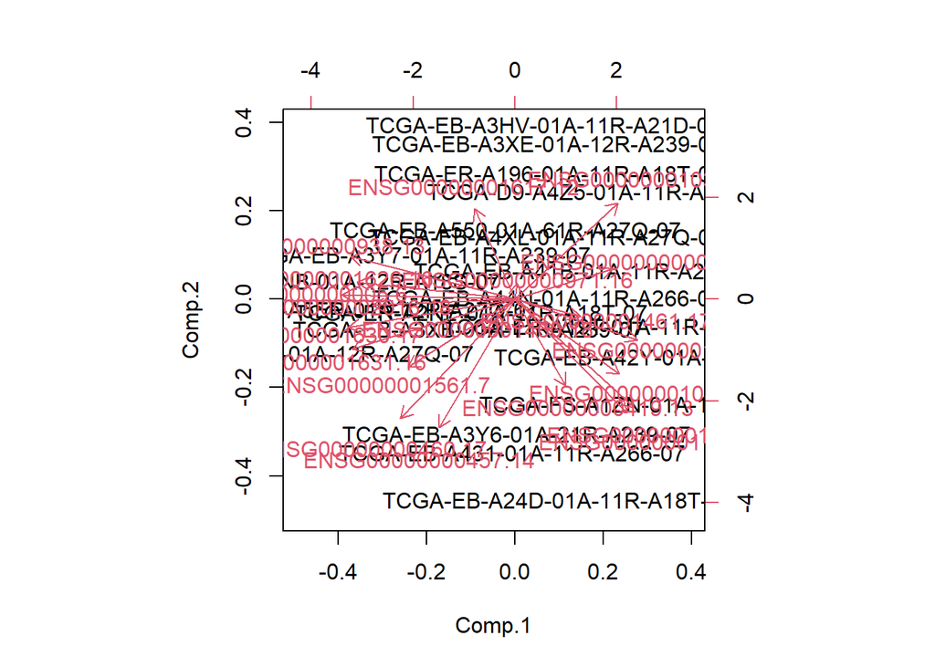

```r
biplot(pcares2)
```

```r
svdres= svd(scale(subset))
svdres$v #as colunas de v são equivalentes aos loadings resultantes da PCA
```

```
##               [,1]        [,2]        [,3]         [,4]         [,5]
##  [1,]  0.187574843 -0.09545462 -0.19566100 -0.047263621  0.579486045
##  [2,] -0.333709830 -0.01401001 -0.11807845 -0.015149190  0.021108055
##  [3,]  0.098228801  0.27381694  0.38998861 -0.078395663 -0.195589734
##  [4,] -0.146530793  0.40656255  0.13876781  0.102224761  0.313787600
##  [5,] -0.220681948  0.37779835  0.05391128 -0.113633990 -0.197964687
##  [6,] -0.317017530 -0.13598408 -0.01552306 -0.009495403  0.008746937
##  [7,]  0.004711682 -0.05037811  0.60113913  0.060984267  0.347286589
##  [8,]  0.198751795 -0.30454332  0.06563640 -0.198877953 -0.146597855
##  [9,]  0.200746681  0.23685516 -0.13868397 -0.334280104  0.213557146
## [10,]  0.215831562  0.36007761 -0.07751624  0.102743132  0.136399424
## [11,] -0.056816924  0.07492407 -0.12557225  0.618093341 -0.224808981
## [12,]  0.125776811  0.05463909  0.05794528  0.553914036  0.126948432
## [13,]  0.236258615  0.12861126 -0.08302238  0.253421454  0.066800891
## [14,] -0.206161763  0.21587048  0.23131612 -0.030380332 -0.090896580
```

[output cut: 69 more lines]

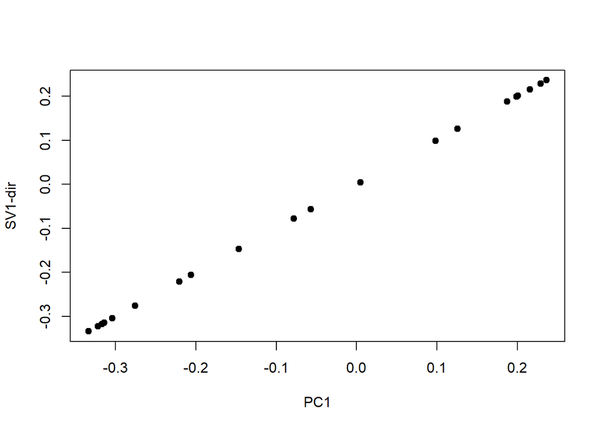

```r
plot(pcares$rotation[,1], svdres$v[,1], pch=19, xlab="PC1", ylab="SV1-dir") #as colunas de v são equivalentes aos loadings resultantes da PCA
```

```r
min(which(summary(pcares)$importance[3,]>0.9))
```

```
## [1] 7
```

## ANÁLISE PREDITIVA

```r
transpose_subset <- transpose[row.names(transpose) %in% row.names(metadata), ]
subset_genes <- rownames(transpose_subset)
metadata_subset <- metadata[subset_genes, ]
rownames(metadata_subset)
```

```
##  [1] "TCGA-EB-A3Y6-01A-21R-A239-07" "TCGA-EB-A4XL-01A-11R-A27Q-07"
##  [3] "TCGA-FS-A1ZN-01A-11R-A18T-07" "TCGA-EB-A3XB-01A-11R-A239-07"
##  [5] "TCGA-EB-A44N-01A-11R-A266-07" "TCGA-EB-A42Y-01A-12R-A24X-07"
##  [7] "TCGA-ER-A196-01A-11R-A18T-07" "TCGA-ER-A2NB-01A-12R-A18S-07"
##  [9] "TCGA-EB-A431-01A-11R-A266-07" "TCGA-EB-A550-01A-61R-A27Q-07"
## [11] "TCGA-D9-A4Z5-01A-11R-A266-07" "TCGA-EB-A3HV-01A-11R-A21D-07"
## [13] "TCGA-EB-A553-01A-12R-A27Q-07" "TCGA-EB-A24D-01A-11R-A18T-07"
## [15] "TCGA-BF-A5ER-01A-12R-A27Q-07" "TCGA-ER-A19T-01A-11R-A18T-07"
## [17] "TCGA-EB-A3Y7-01A-11R-A239-07" "TCGA-EB-A3XE-01A-12R-A239-07"
## [19] "TCGA-EB-A41B-01A-11R-A24X-07" "TCGA-ER-A2NF-01A-11R-A18T-07"
## [21] "TCGA-BF-A3DJ-01A-11R-A20F-07" "TCGA-EB-A44P-01A-11R-A266-07"
## [23] "TCGA-EB-A4OY-01A-11R-A266-07" "TCGA-EB-A299-01A-21R-A18U-07"
## [25] "TCGA-IH-A3EA-01A-11R-A20F-07" "TCGA-D9-A3Z4-01A-11R-A239-07"
## [27] "TCGA-EB-A3XD-01A-22R-A239-07" "TCGA-EB-A430-01A-11R-A24X-07"
## [29] "TCGA-EB-A44O-01A-11R-A266-07" "TCGA-ER-A42H-01A-11R-A24X-07"
```

[output cut: 18 more lines]

Aqui igualamos as linhas do dataset da transposta com o do metadata.

```r
transpose_subset_df <- as.data.frame(transpose_subset)
metadata_subset_df <- data.frame(coluna = metadata_subset$vital_status, stringsAsFactors = FALSE)
res_df <- data.frame(transpose_subset_df, metadata_subset_df)
```

De seguida juntamos a coluna viral_status (Alive or Dead) dos metadados ao dataset da transposta.

```r
set.seed(12345)
ind = sample(2, nrow(res_df), replace=TRUE, prob=c(0.7, 0.3))
trainData = res_df[ind==1,]
testData = res_df[ind==2,]
table(trainData$coluna)
```

```
##
## Alive  Dead
##    29    13
```

```r
table(testData$coluna)
```

```
##
## Alive  Dead
##    17     7
```

## Método dos k vizinhos mais próximos

```r
knn_pred = knn(trainData[,1:4], testData[,1:4], trainData$coluna)
knn_pred #resultado: valores previstos para a variável de saída
```

```
##  [1] Dead  Alive Alive Alive Alive Alive Dead  Alive Alive Alive Dead  Alive
## [13] Alive Dead  Alive Alive Alive Alive Alive Alive Alive Dead  Alive Alive
## Levels: Alive Dead
```

```r
pecc = function(obs,pred)sum(obs==pred)/length(obs)
t = table(knn_pred, testData$coluna)
t
```

```
##
## knn_pred Alive Dead
##    Alive    12    7
##    Dead      5    0
```

```r
pecc(knn_pred, testData$coluna) #medidas de erro kNN
```

```
## [1] 0.5
```

## TREINO DO MODELO

```r
trainMatrix <- as.matrix(trainData[, 1:4])
trainLabel <- trainData$coluna

testMatrix <- as.matrix(testData[, 1:4])
testLabel <- testData$coluna
```

### Estimativa do modelo

```r
logitModel <- glmnet(trainMatrix, trainLabel, family = "binomial")
```

### Previsão do modelo

```r
logitPred <- predict(logitModel, newx = testMatrix, type = "response")
logitPred <- ifelse(logitPred > 0.5, 1, 0)
```

### Avaliação da accuracy do modelo

```r
logitAccuracy <- sum(logitPred == testLabel) / length(testLabel)
logitAccuracy
```

```
## [1] 0
```

Neste caso o valor da accuracy é 0, o que significa que os valores de testLabel são diferentes de logitPred, isto pode querer dizer que o modelo não está a prever corretamente os dados.

## ÁRVORE DE DECISÃO

```r
trainMatrix <- as.matrix(trainData[, 1:4])
trainLabel <- trainData$coluna

testMatrix <- as.matrix(testData[, 1:4])
testLabel <- testData$coluna

dtModel <- rpart(trainLabel ~ ., data = trainData[, 1:4])

dtPred <- predict(dtModel, newdata = testData[, 1:4], type = "class")

dtAccuracy <- sum(dtPred == testLabel) / length(testLabel)
dtAccuracy
```

```
## [1] 0.5416667
```

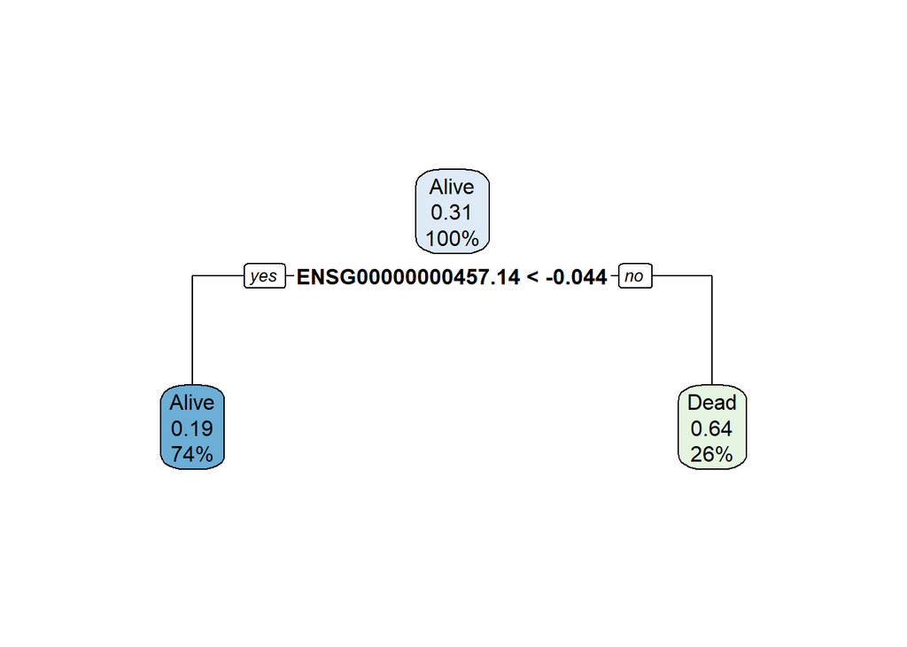

```r
rpart.plot(dtModel)
```

No gráfico é observável 74% de Alive contra 26% de Dead.